# MATH 424 Final

Hannah Lo

12/17/2019

## Introduction

The gaussian elimination with partial pivoting from homework 8 was altered to compute the inverse of a square matrix A rather than the solution to Ax=C. To complete this, the matrix C was changed to the identity matrix of the same dimension of A.

Using matmul on the calculated inverse of A and the original A matrix, the calculated identity matrix was found. The error was computed by the difference between the identity matrix and the calculated identity matrix.

Initializing the identity and augmented matrix was included in the timing since it is part of solving for the inverse using gaussian elimination with partial pivoting.

## Serial Optimization

No conditional statements could be moved outside of a loop from the original code. All possible cases of replacing divisions by multiplications were completed. The formation of the augmented matrix B was rewritten to allow stride 1 access. However, no other loops could be rewritten without changing their function.

```r
! make augmented matrix B
   do i = 1,m
      B(1:m,i) = A(1:m,i)
      B(1:m,(m+i)) = Id(1:m,i)
   enddo
```

In addition, Loop Fusion was tried by collapsing the formation of the identity matrix and augmented B matrix into one loop. This did not bring a noticeable difference.

```r
! make augmented matrix B and identity matrix simulatenously
   Id = 0
   do i = 1,m
      Id(i,i) = 1.d0
      B(1:m,i) = A(1:m,i)
      B(1:m,(m+i)) = Id(1:m,i)
   enddo
```

Vectorization was added to the `interchange` step where the index row is swapped with the current row, the step where the `augmented matrix and identity matrix are formed`, and where the `row i is divided by by B(i,i) from columns i to n`. The following is showing the interchange step:

```r
       !dir$ simd
        do j = i,n
            tmp = B(index,j)
            B(index,j) = B(i,j)
            B(i,j) = tmp
        enddo
```

Block caching was tried by two different placements on the `zeroing column` step. The first placement was at the first loop and the second placement ws only on the inner loop. The inner loop placement proved to outperform both the outer loop placement and not having block caching at all.

```r
      ! zero column
      do j = 1,m
               if (i/=j) then
                  alpha = -(B(j,i))
                  !dir$ block_loop
                  do kk = i+1,n
                     B(j,kk) = B(j,kk) +alpha*B(i,kk)
                  enddo
                  B(j,i) = 0.d0
              endif
      enddo
```

## MAP Profiling

Map was very useful for me to focus on optimizing my code where it was slowing down the most. There were two main parts that my program spent most of its time on.

The following is the first slow part. It is the preparing step to check if `the matrix is numerically singular`.

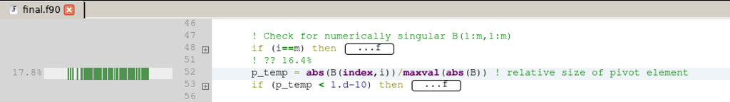

This section was taking 17.8% of the time.

A couple of different ways to optimize were tried. The division by the maximum value of B was changed to multiplication by introducing a tmp value. This however did not improve performance.

```r
      tmp = 1.d0/maxval(abs(B))
      p_temp = abs(B(index,i))*tmp
```

The next step was to try separating the `maxval` function and division to identify what was slowing the program. This revealed that the function `maxval` was causing the slowdown.

```r
      tmp = maxval(abs(B))
      p_temp = abs(B(index,i))/tmp
```

The `dlange()` function from LAPACK was chosen to replace this function to see if it was optimized better than `maxval`. In addition, different `-mkl compiler options` were tried in combinatin. Each program version was ran three times with each program having 12 timing trials. However, the best combination was shown to be the original function `maxval` and `-mkl=sequential`.

| FUNCTION | -mkl compiler | GFLOPS |
| --- | --- | --- |
| **maxval** | **sequential** | **18.8462** |
| maxval | parallel | 18.7958 |
| dlange | sequential | 18.1703 |
| dlange | parallel | 17.8056 |

The following is the second slow part. It is the `zeroing column` step that I used cache blocking on. This is where I will focus my parellization for optimization.

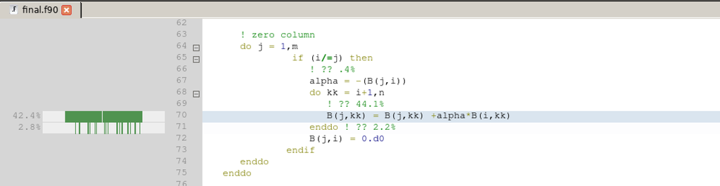

This section was taking 42.4% of the time.

## Parallel Optimization

I was able to compare parallelizing the outer versus the inner loop of the `zeroing column` step. The inner loop was a race condition and needed a reduction clause; however, this version of the program would continuously run and hit the max time limit. The best performance was the parallelization of the outer do loop.

```r
! ZERO COLUMN

!$omp parallel default(none) shared(B,i,alpha) private(j,kk)
!$omp do schedule(static)
      do j = 1,m
               if (i/=j) then
                  alpha = -(B(j,i))
                  do kk = i+1,n
                     B(j,kk) = B(j,kk) +alpha*B(i,kk)
                  enddo
                B(j,i) = 0.d0
              endif
      enddo
!$omp enddo
!$omp end parallel
```

Different scheduling options were experimented with, showing that static had the biggest positive impact on performance.

| Scheduling | GFLOPS |
| --- | --- |
| **static** | **109.3905** |
| dynamic | 45.3653 |
| guided | 101.4147 |
| auto | 103.1746 |

## Conclusion

The final parallel speedup was calculated to be `5.80438`.

```r
parallel_speedup = 109.3905/18.8462
print(parallel_speedup)
```

```
## [1] 5.80438
```

## References

- dlange() : http://www.netlib.org
- http://computer-programming-forum.com/49-fortran/f6d88a45ec9c7cbb.htm
- Professor Luecke handouts